# Employee Turnover Prediction - HR Analytics

There are three important things covered:

```
1) Descriptive Analytics - What happened?
2) Predictive Analytics - What might happen?
3) Prescriptive Analytics - What action should be taken?
```

### Problem:

One of the most common problems for a company is **turnover**.

In the context of human resources, turnover is the act of replacing an employee with a new employee. Few of the reasons could be resignations, terminations, transfers, retirements, deaths, etc.

As per the Center of American Progress, replacing a worker earning about **50,000 dollars** cost the company about **10,000 dollars** or 20% of that worker's yearly income.

**Cost includes:** (There could be many factors that add to turnover cost.Few of the important ones are listed below)

- Off-boarding cost
- Hiring costs (advertising, interviewing, hiring)
- Cost of onboarding a new person (training, management time)
- Cost of Overtime payments to employees who cover the left employee's work.
- Lost productivity (a new employee usually takes 1-2 years to reach the productivity of an existing employee)

**Annual Cost of Turnover** = (hiring + onboarding + unfilled time + other costs) x (# Employees x Annual Turnover Percentage)

**Annual Cost of Turnover** = (1000 + 500) x (15,000 x 24%)

**Annual Cost of Turnover** = 5400000

### Example

1. Jobs(earning under 30k a year) - the cost to replace a 10 dollar/hour retail employee would be ~3300 dollars.
2. Jobs(earning a 30k-50k a year) - the cost to replace a 40k manager would be ~8000 dollars.
3. Jobs of executives (earning 100k+ a year) - the cost to replace a 100k CEO is ~213,000 dollars.

## Problem Definition:

To design a predictive model based on the historic employee turnover data for estimating the probability whether an employee turnovers or not and accordingly design a system of actions to be taken to reduce the turnover rate and improve the workforce retention. Hence, significantly reducing the high costs incurred on the organization.

## Read the Data

```python
from pandas import read_csv
import pandas as pd
import numpy as np
import matplotlib.pyplot as plt
import seaborn as sns
%matplotlib inline
```

```python
path = "C:/Users/sac/Downloads/DSDJ/PracticeProjects/HR_Analytics/HR-data.csv"
```

```python
dataset_df = read_csv(path)
```

```python
dataset_df.head()
```

|  | satisfaction_level | last_evaluation | number_project | average_montly_hours | time_spend_company | Work_accident | left | promotion_last_5years | sales | salary |
| --- | --- | --- | --- | --- | --- | --- | --- | --- | --- | --- |
| 0 | 0.38 | 0.53 | 2 | 157 | 3 | 0 | 1 | 0 | sales | low |
| 1 | 0.80 | 0.86 | 5 | 262 | 6 | 0 | 1 | 0 | sales | medium |
| 2 | 0.11 | 0.88 | 7 | 272 | 4 | 0 | 1 | 0 | sales | medium |
| 3 | 0.72 | 0.87 | 5 | 223 | 5 | 0 | 1 | 0 | sales | low |
| 4 | 0.37 | 0.52 | 2 | 159 | 3 | 0 | 1 | 0 | sales | low |

## Data Quality Check

```python
# check to see if there are any missing values in our dataset
dataset_df.isnull().any()
```

```
satisfaction_level       False
last_evaluation          False
number_project           False
average_montly_hours     False
time_spend_company       False
Work_accident            False
left                     False
promotion_last_5years    False
sales                    False
salary                   False
dtype: bool
```

```python
# another way to check for missing values
dataset_df.isnull().sum()
```

```
satisfaction_level       0
last_evaluation          0
number_project           0
average_montly_hours     0
time_spend_company       0
Work_accident            0
left                     0
promotion_last_5years    0
sales                    0
salary                   0
dtype: int64
```

```python
# renaming columns for better readability
dataset_df = dataset_df.rename(columns = {'satisfaction_level': 'satisfaction',
                                          'last_evaluation' : 'evaluation',
                                          'number_project' : 'projectCount',
                                          'average_montly_hours' : 'avgMonthlyHours',
                                          'time_spend_company' : 'yearsAtCompany',
                                          'Work_accident' : 'workAccident',
                                          'left' : 'turnover',
                                          'promotion_last_5years' : 'promotion',
                                          'sales' : 'department',
                                         })
```

```python
# check the data types if there are any discrepancies.
dataset_df.dtypes
```

```
satisfaction       float64
evaluation         float64
projectCount         int64
avgMonthlyHours      int64
yearsAtCompany       int64
workAccident         int64
turnover             int64
promotion            int64
department          object
salary              object
dtype: object
```

```python
dataset_df.info()
```

```
<class 'pandas.core.frame.DataFrame'>
RangeIndex: 14999 entries, 0 to 14998
Data columns (total 10 columns):
 #   Column           Non-Null Count  Dtype
---  ------           --------------  -----
 0   satisfaction     14999 non-null  float64
 1   evaluation       14999 non-null  float64
 2   projectCount     14999 non-null  int64
 3   avgMonthlyHours  14999 non-null  int64
 4   yearsAtCompany   14999 non-null  int64
 5   workAccident     14999 non-null  int64
 6   turnover         14999 non-null  int64
 7   promotion        14999 non-null  int64
 8   department       14999 non-null  object
 9   salary           14999 non-null  object
dtypes: float64(2), int64(6), object(2)
memory usage: 1.1+ MB
```

## Exploratory Data Analysis

```python
# how many employees are in the dataset?
dataset_df.shape
```

```
(14999, 10)
```

```python
# calculate the turnover rate of this company dataset
turnover_rate = dataset_df['turnover'].value_counts() / dataset_df.shape[0]
```

```python
turnover_rate
```

```
0    0.761917
1    0.238083
Name: turnover, dtype: float64
```

```python
# display the statistical description
dataset_df.describe()
```

|  | satisfaction | evaluation | projectCount | avgMonthlyHours | yearsAtCompany | workAccident | turnover | promotion |
| --- | --- | --- | --- | --- | --- | --- | --- | --- |
| count | 14999.000000 | 14999.000000 | 14999.000000 | 14999.000000 | 14999.000000 | 14999.000000 | 14999.000000 | 14999.000000 |
| mean | 0.612834 | 0.716102 | 3.803054 | 201.050337 | 3.498233 | 0.144610 | 0.238083 | 0.021268 |
| std | 0.248631 | 0.171169 | 1.232592 | 49.943099 | 1.460136 | 0.351719 | 0.425924 | 0.144281 |
| min | 0.090000 | 0.360000 | 2.000000 | 96.000000 | 2.000000 | 0.000000 | 0.000000 | 0.000000 |
| 25% | 0.440000 | 0.560000 | 3.000000 | 156.000000 | 3.000000 | 0.000000 | 0.000000 | 0.000000 |
| 50% | 0.640000 | 0.720000 | 4.000000 | 200.000000 | 3.000000 | 0.000000 | 0.000000 | 0.000000 |
| 75% | 0.820000 | 0.870000 | 5.000000 | 245.000000 | 4.000000 | 0.000000 | 0.000000 | 0.000000 |
| max | 1.000000 | 1.000000 | 7.000000 | 310.000000 | 10.000000 | 1.000000 | 1.000000 | 1.000000 |

```python
# display the mean summary of Employees (turnover v.s non-turnover). What do we notice between the groups?
turnover_Summary = dataset_df.groupby('turnover')
turnover_Summary.mean()
```

| turnover | satisfaction | evaluation | projectCount | avgMonthlyHours | yearsAtCompany | workAccident | promotion |
| --- | --- | --- | --- | --- | --- | --- | --- |
| 0 | 0.666810 | 0.715473 | 3.786664 | 199.060203 | 3.380032 | 0.175009 | 0.026251 |
| 1 | 0.440098 | 0.718113 | 3.855503 | 207.419210 | 3.876505 | 0.047326 | 0.005321 |

## Correlation Matrix

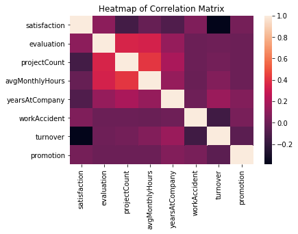

```python
# let's create a correlation matrix. What features correlate the most with turnover?
corr = dataset_df.corr()
sns.heatmap(corr , xticklabels=corr.columns.values, yticklabels=corr.columns.values)
plt.title("Heatmap of Correlation Matrix")
plt.show()
```

```python
corr
```

|  | satisfaction | evaluation | projectCount | avgMonthlyHours | yearsAtCompany | workAccident | turnover | promotion |
| --- | --- | --- | --- | --- | --- | --- | --- | --- |
| satisfaction | 1.000000 | 0.105021 | -0.142970 | -0.020048 | -0.100866 | 0.058697 | -0.388375 | 0.025605 |
| evaluation | 0.105021 | 1.000000 | 0.349333 | 0.339742 | 0.131591 | -0.007104 | 0.006567 | -0.008684 |
| projectCount | -0.142970 | 0.349333 | 1.000000 | 0.417211 | 0.196786 | -0.004741 | 0.023787 | -0.006064 |
| avgMonthlyHours | -0.020048 | 0.339742 | 0.417211 | 1.000000 | 0.127755 | -0.010143 | 0.071287 | -0.003544 |
| yearsAtCompany | -0.100866 | 0.131591 | 0.196786 | 0.127755 | 1.000000 | 0.002120 | 0.144822 | 0.067433 |
| workAccident | 0.058697 | -0.007104 | -0.004741 | -0.010143 | 0.002120 | 1.000000 | -0.154622 | 0.039245 |
| turnover | -0.388375 | 0.006567 | 0.023787 | 0.071287 | 0.144822 | -0.154622 | 1.000000 | -0.061788 |
| promotion | 0.025605 | -0.008684 | -0.006064 | -0.003544 | 0.067433 | 0.039245 | -0.061788 | 1.000000 |

## EDA 1.

### Distribution of Satisfaction, Evaluation, and Average Monthly Hours

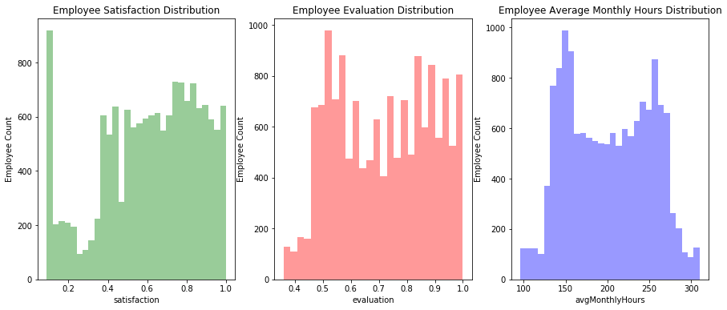

```python
# plot the distribution of Employee Satisfaction, Evaluation, and Average Monthly Hours. What story can you tell?
# setup the matplotlib figure
fig , axes = plt.subplots(ncols=3, figsize=(15,6))
sns.distplot(dataset_df['satisfaction'], kde=False, color='g', ax=axes[0]).set_title("Employee Satisfaction Distribution")
axes[0].set_ylabel("Employee Count")

sns.distplot(dataset_df['evaluation'], kde=False, color='r', ax=axes[1]).set_title("Employee Evaluation Distribution")
axes[1].set_ylabel("Employee Count")

sns.distplot(dataset_df['avgMonthlyHours'], kde=False, color='b', ax=axes[2]).set_title("Employee Average Monthly Hours Distribution")
axes[2].set_ylabel("Employee Count")

plt.show()
```

## EDA 2.

### Satisfaction vs Evaluation

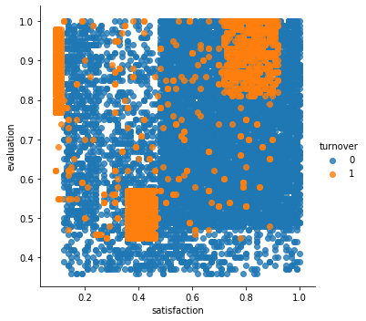

```python
sns.lmplot(x='satisfaction', y='evaluation', data=dataset_df, hue='turnover', fit_reg=False)
plt.show()
```

We can see, there are 3 distinct clusters of employees who left the company.

```
Cluster 1 : Hard-working and Sad Employees
    What could be the reason to feel sad when you are highly evaluated? Is it working too hard? Could this cluster mean employees who are 'overworked'?

Cluster 2 : Bad at work and Sad Employees
    Could this cluster mean employees who 'under-performed'?

Cluster 3 : Hard-working and Happy Employees
    Could this cluster mean that employees left because they found another job opportunity?
```

### K-Means Clustering of Employee Turnover

```python
from sklearn.cluster import KMeans
```

```python
# Create and graph 3 cluster of Employee Turnover
kmeans = KMeans(n_clusters=3, random_state=7)
```

```python
kmeans.fit(dataset_df[dataset_df['turnover']==1][['satisfaction','evaluation']])
kmeans_color = ['green' if c == 0 else 'blue' if c == 2 else 'red' for c in kmeans.labels_]  # different color for each cluster
```

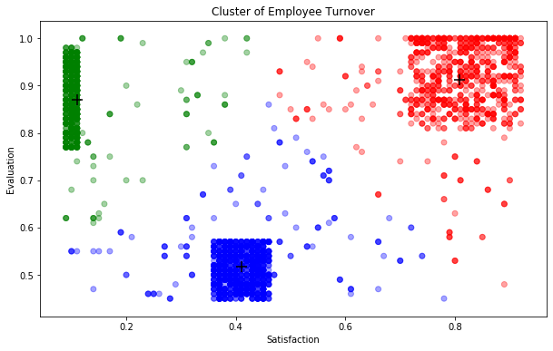

```python
fig = plt.figure(figsize=(10,6))
plt.scatter(x="satisfaction", y="evaluation", data=dataset_df[dataset_df['turnover']==1], color = kmeans_color, alpha=0.36)
plt.title("Cluster of Employee Turnover")
plt.xlabel("Satisfaction")
plt.ylabel("Evaluation")
# plot the center of each cluster
plt.scatter(kmeans.cluster_centers_[:,0], kmeans.cluster_centers_[:,1], marker='+', s=144, c='black')
plt.show()
```

## EDA 3. Employee Satisfaction

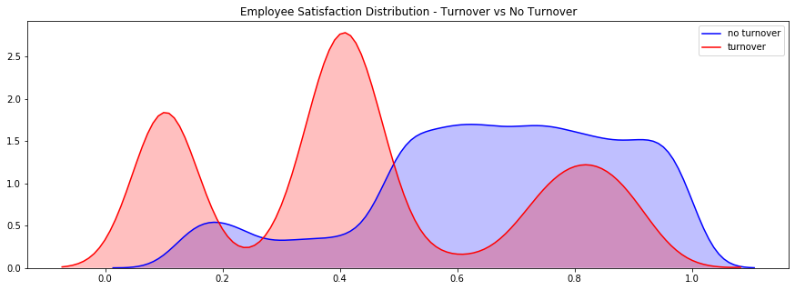

```python
# Kernel Density Estimate Plot
fig = plt.figure(figsize=(15,5))
sns.kdeplot(dataset_df[dataset_df['turnover']==0]['satisfaction'], color='b', shade=True, label='no turnover')
sns.kdeplot(dataset_df[dataset_df['turnover']==1]['satisfaction'], color='r', shade=True, label='turnover')
plt.title("Employee Satisfaction Distribution - Turnover vs No Turnover")
plt.show()
```

It is a **tri-modal** distribution for employees that overturned

```
 - Employees with very low satisfaction levels (0.2 or less) left the company more
 - Employees with low satisfaction levels (0.3 ~ 0.5) left the company more
 - Employees with vey high satisfaction levels (0.7 or more) left the company more
```

## EDA 4. Employee Project Count

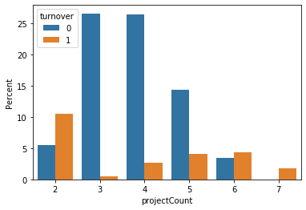

```python
ax = sns.barplot(x='projectCount', y='projectCount', hue='turnover', data=dataset_df, estimator=lambda n : len(n) / len(dataset_df)*100)
ax.set_ylabel("Percent")
plt.show()
```

Summary :

[output not shown]

## EDA 5. Employee Department Distribution

```python
hrleft = dataset_df[dataset_df['turnover']==1]
```

```python
hrleft = hrleft['department'].value_counts().reset_index()  # reset_index() resets the index of the DataFrame
```

```python
hrtotal = dataset_df['department'].value_counts().reset_index()
```

```python
# merge both the dataframes into one.
hr_merge =  pd.merge(hrleft, hrtotal, how='inner', on = 'index')  # 'inner' join on index
```

```python
# rename the columns to more readable names
hr_merge = hr_merge.rename(columns = {'index':'department', 'department_x':'left', 'department_y':'total'})
```

```python
hr_merge
```

|  | department | left | total |
| --- | --- | --- | --- |
| 0 | sales | 1014 | 4140 |
| 1 | technical | 697 | 2720 |
| 2 | support | 555 | 2229 |
| 3 | IT | 273 | 1227 |
| 4 | hr | 215 | 739 |
| 5 | accounting | 204 | 767 |
| 6 | marketing | 203 | 858 |
| 7 | product_mng | 198 | 902 |
| 8 | RandD | 121 | 787 |
| 9 | management | 91 | 630 |

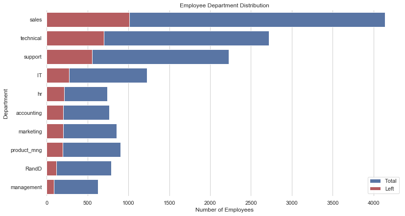

```python
sns.set(style='whitegrid')
f, ax = plt.subplots(figsize=(13,7))

sns.barplot(x='total', y='department', data=hr_merge, color = 'b', label='Total')
sns.barplot(x='left', y='department', data=hr_merge, color = 'r', label='Left')

ax.legend()
ax.set(xlabel="Number of Employees", ylabel="Department", title="Employee Department Distribution")

sns.despine(left=True, bottom=True)  # removes the left and bottom spines from plot

plt.show()
```

Summary :

```
   - All the departments had faced turnover.
   - Sales, technical and support departments experienced turnover of more than 500 employees. What could be the reason? Did they feel their work as monotonous or lost interest?
   - No department had seen a turnover of near or more than 50%.
```

## EDA 5. Average Monthly Hours

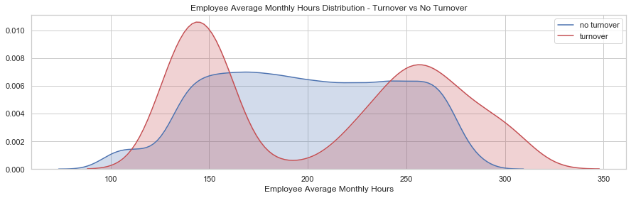

```python
fig = plt.figure(figsize=(15,4))
ax = sns.kdeplot(dataset_df[dataset_df['turnover']==0]['avgMonthlyHours'], shade=True, color='b', label='no turnover')
ax = sns.kdeplot(dataset_df[dataset_df['turnover']==1]['avgMonthlyHours'], shade=True, color='r', label='turnover')

ax.set(xlabel="Employee Average Monthly Hours" ,title="Employee Average Monthly Hours Distribution - Turnover vs No Turnover")
plt.show()
```

Summary:

```
- A bi-modal distribution for employees that overturned.
- Significantly, employees who had less hours of work(~150 hours or less) left the company.
- Significantly, employees who had too many work hours(~250 or more) left the company.
- Employees who left generally were either underworked or overworked.
```

## Pre-processing

- Separate categorical and numerical variables.
- Apply get_dummies() to the categorical variables.
- Then combine both of them.

```python
category_var = ['department','salary','turnover','promotion']
num_var = ['satisfaction','evaluation','projectCount','avgMonthlyHours','yearsAtCompany','workAccident']
```

```python
categorical_df = pd.get_dummies(dataset_df[category_var], drop_first=True)
numerical_df = dataset_df[num_var]
```

```python
new_dataset_df = pd.concat([categorical_df, numerical_df], axis=1)
```

```python
new_dataset_df.head()
```

|  | turnover | promotion | department_RandD | department_accounting | department_hr | department_management | department_marketing | department_product_mng | department_sales | department_support | department_technical | salary_low | salary_medium | satisfaction | evaluation | projectCount | avgMonthlyHours | yearsAtCompany | workAccident |
| --- | --- | --- | --- | --- | --- | --- | --- | --- | --- | --- | --- | --- | --- | --- | --- | --- | --- | --- | --- |
| 0 | 1 | 0 | 0 | 0 | 0 | 0 | 0 | 0 | 1 | 0 | 0 | 1 | 0 | 0.38 | 0.53 | 2 | 157 | 3 | 0 |
| 1 | 1 | 0 | 0 | 0 | 0 | 0 | 0 | 0 | 1 | 0 | 0 | 0 | 1 | 0.80 | 0.86 | 5 | 262 | 6 | 0 |
| 2 | 1 | 0 | 0 | 0 | 0 | 0 | 0 | 0 | 1 | 0 | 0 | 0 | 1 | 0.11 | 0.88 | 7 | 272 | 4 | 0 |
| 3 | 1 | 0 | 0 | 0 | 0 | 0 | 0 | 0 | 1 | 0 | 0 | 1 | 0 | 0.72 | 0.87 | 5 | 223 | 5 | 0 |
| 4 | 1 | 0 | 0 | 0 | 0 | 0 | 0 | 0 | 1 | 0 | 0 | 1 | 0 | 0.37 | 0.52 | 2 | 159 | 3 | 0 |

## Class Imbalance

### Employee Turnover Rate : 24%

```python
dataset_df.turnover.value_counts(normalize=True)  # normalize gives the relative frequencies of the unique values
```

```
0    0.761917
1    0.238083
Name: turnover, dtype: float64
```

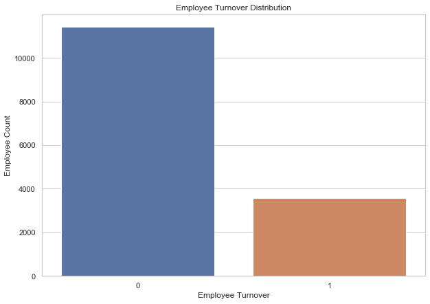

```python
plt.figure(figsize=(10,7))
turnover = dataset_df.turnover.value_counts()
ax = sns.barplot(y=turnover.values, x=turnover.index, data=dataset_df)
ax.set(xlabel="Employee Turnover", ylabel="Employee Count", title="Employee Turnover Distribution")
plt.show()
```

We can see that the dataset is highly imbalanced.

## How to treat Imbalanced Datasets

There are many ways of dealing with imbalanced data. Let's try:

```
       Oversampling - SMOTE
       Undersampling - RandomUnderSampler
```

## Split Train/Test set

```python
from sklearn.model_selection import train_test_split
from sklearn.metrics import accuracy_score, classification_report, precision_score, recall_score, confusion_matrix ,precision_recall_curve, roc_auc_score
```

```python
data = new_dataset_df.values
X = data[:,1:]            # output variable 'turnover' is in index 0. Hence we start from index 1
y = data[:,0]             # output variable 'turnover' is selected.
```

```python
X_train, X_test, y_train, y_test = train_test_split(X, y, test_size=0.20, random_state=7, stratify=y)
```

## Resample Methods

```
1. Original Sample
2. Upsampling Data
3. Downsampling Data
```

```python
from sklearn.utils import resample
from imblearn.over_sampling import SMOTE   #in case u need, install 'imblearn' package using 'pip install imblearn'
```

```python
# upsample minority class
X_train_u, y_train_u = resample(X_train[y_train == 1], y_train[y_train == 1],      # minority class to be upsampled
                                replace=True,                                      # resampling with replacement
                                n_samples=X_train[y_train==0].shape[0],            # number of samples to generate
                                random_state=1)

X_train_u = np.concatenate((X_train[y_train==0], X_train_u))
y_train_u = np.concatenate((y_train[y_train==0], y_train_u))
```

```python
# Upsample using SMOTE (Synthetic Minority Over-sampling Technique)
sm = SMOTE(random_state=7)
X_train_sm, y_train_sm = sm.fit_sample(X_train, y_train)
```

```python
# Downsample majority class
X_train_d, y_train_d = resample(X_train[y_train==0], y_train[y_train==0],
                                replace=True,
                                n_samples=X_train[y_train==1].shape[0],
                                random_state=1
                               )
X_train_d = np.concatenate((X_train[y_train==1], X_train_d))
y_train_d = np.concatenate((y_train[y_train==1], y_train_d))
```

```python
print("Original data shape:\t", X_train.shape, y_train.shape)
print("Upsampled data shape:\t", X_train_u.shape, y_train_u.shape)
print("SMOTE data shape:\t", X_train_sm.shape, y_train_sm.shape)
print("Downsampled data shape:\t", X_train_d.shape, y_train_d.shape)
```

```
Original data shape:	 (11999, 18) (11999,)
Upsampled data shape:	 (18284, 18) (18284,)
SMOTE data shape:	 (18284, 18) (18284,)
Downsampled data shape:	 (5714, 18) (5714,)
```

## Choose which Sampling Technique to Use for Model

```
Let's apply 5-Fold Cross Validation for Logistic Regression on original and all other sampled data.
```

```python
from sklearn.linear_model import LogisticRegression
from sklearn.model_selection import cross_val_score
```

```python
methods_data = {"Original" : (X_train, y_train),
                "Upsampled": (X_train_u, y_train_u),
                "SMOTE"    : (X_train_sm, y_train_sm),
                "Downsampled":(X_train_d, y_train_d)
               }
```

```python
model = LogisticRegression(solver='liblinear',random_state=7, max_iter=99)
```

```python
for method in methods_data.keys():
    results = cross_val_score(model, methods_data[method][0], methods_data[method][1], cv=5, scoring="f1")
    print("The F1 score for %s data: %f" % (method, results.mean()))
```

```
The F1 score for Original data: 0.448081
The F1 score for Upsampled data: 0.773914
The F1 score for SMOTE data: 0.784270
The F1 score for Downsampled data: 0.764088
```

SMOTE sampled data gives the best performance.

## Logistic Regression F1-Score

```python
logreg = LogisticRegression(solver='liblinear')

logreg.fit(X_train_sm, y_train_sm)

yhat = logreg.predict(X_test)

logreg_auc = roc_auc_score(y_test, yhat)
print("Logistic Regression AUC ROC: %.2f\n\n" % logreg_auc)

print(classification_report(y_test, yhat))
```

```
Logistic Regression AUC ROC: 0.77


              precision    recall  f1-score   support

         0.0       0.92      0.75      0.83      2286
         1.0       0.50      0.80      0.61       714

    accuracy                           0.76      3000
   macro avg       0.71      0.77      0.72      3000
weighted avg       0.82      0.76      0.78      3000
```

## Random Forest Classifier

### Apply 5-fold Cross validation

```python
from sklearn.ensemble import RandomForestClassifier

rndfrt = RandomForestClassifier()

results = cross_val_score(rndfrt, X_train_sm, y_train_sm, scoring='f1',cv=5)
print("F1-Score:%.3f" % results.mean())
```

```
F1-Score:0.990
```

### ROC AUC and Classification Report

```python
rndfrt.fit(X_train_sm, y_train_sm)

yhat = rndfrt.predict(X_test)

rndfrt_roc_auc = roc_auc_score(y_test, yhat)
print("Random Forest AUC ROC:%.2f\n\n" % rndfrt_roc_auc)

print(classification_report(y_test, yhat))
```

```
Random Forest AUC ROC:0.98


              precision    recall  f1-score   support

         0.0       0.99      1.00      0.99      2286
         1.0       0.99      0.97      0.98       714

    accuracy                           0.99      3000
   macro avg       0.99      0.98      0.99      3000
weighted avg       0.99      0.99      0.99      3000
```

## Gradient Boosting

### Apply 5-fold Cross validation

```python
from sklearn.ensemble import GradientBoostingClassifier

gdboost = GradientBoostingClassifier()

results = cross_val_score(gdboost, X_train_sm, y_train_sm, scoring='f1', cv=5)
print("F1-Score: %.3f" % results.mean())
```

```
F1-Score: 0.971
```

### ROC AUC and Classification Report

```python
gdboost.fit(X_train_sm, y_train_sm)

yhat = gdboost.predict(X_test)

gdboost_roc_auc = roc_auc_score(y_test, yhat)
print("Gradient Boosting Classifier ROC AUC:%.3f\n\n" % gdboost_roc_auc)

print(classification_report(y_test, yhat))
```

```
Gradient Boosting Classifier ROC AUC:0.956


              precision    recall  f1-score   support

         0.0       0.98      0.98      0.98      2286
         1.0       0.92      0.94      0.93       714

    accuracy                           0.97      3000
   macro avg       0.95      0.96      0.95      3000
weighted avg       0.97      0.97      0.97      3000
```

## ROC Graph

```python
from sklearn.metrics import roc_curve
```

```python
fpr, tpr, thresholds = roc_curve(y_test, logreg.predict_proba(X_test)[:, 1])
# target scores should be of the positive class. i.e we choose only 1st row of the predict_proba.
rndfrt_fpr, rndfrt_tpr, rndfrt_thresholds = roc_curve(y_test, rndfrt.predict_proba(X_test)[:, 1])
gdboost_fpr, gdboost_tpr, gdboost_thresholds = roc_curve(y_test, gdboost.predict_proba(X_test)[:, 1])
```

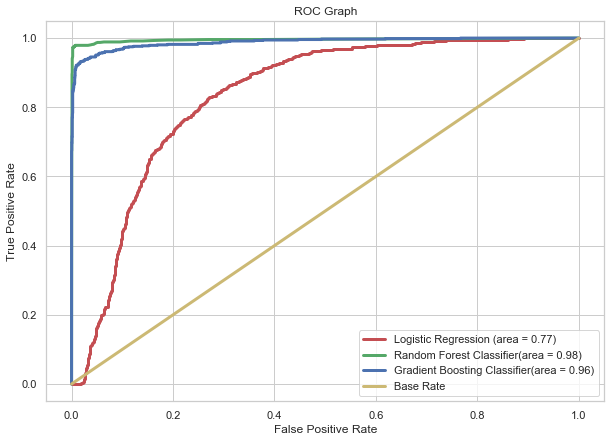

```python
plt.figure(figsize=(10,7))

# Logistic Regression ROC
plt.plot(fpr, tpr, color='r', linewidth=3, label="Logistic Regression (area = %.2f)" % logreg_auc)

# Random Forest Classifier ROC
plt.plot(rndfrt_fpr, rndfrt_tpr, color='g', linewidth=3, label="Random Forest Classifier(area = %.2f)" % rndfrt_roc_auc)

#Gradient Boosting Classifier ROC
plt.plot(gdboost_fpr, gdboost_tpr, color='b', linewidth=3, label="Gradient Boosting Classifier(area = %.2f)" % gdboost_roc_auc)

#Base Rate ROC
plt.plot([0,1],[0,1], color='y', linewidth=3, label="Base Rate")

plt.title("ROC Graph")
plt.xlabel("False Positive Rate")
plt.ylabel("True Positive Rate")
plt.legend()         # displays all labels
plt.show()
```

## Confusion Matrix

```python
print("Logistic Regression:")
confusion_matrix(y_test, logreg.predict(X_test))
```

```
Logistic Regression:
```

```
array([[1712,  574],
       [ 146,  568]], dtype=int64)
```

```python
print("Random Forest Classifier:")
confusion_matrix(y_test, rndfrt.predict(X_test))
```

```
Random Forest Classifier:
```

```
array([[2276,   10],
       [  19,  695]], dtype=int64)
```

```python
print("Gradient Boosting Classifier:")
confusion_matrix(y_test, gdboost.predict(X_test))
```

```
Gradient Boosting Classifier:
```

```
array([[2231,   55],
       [  46,  668]], dtype=int64)
```

Summary :

[output not shown]

## Recall or Precision?

It depends on how much cost/weight one bears on the two types of error: 1)False Positives or 2)False Negatives

What's the cost of having a FN or a FP?

Optimize Recall when:

```
 1.You want to limit False Negatives.
 2.FN > FP
 3.e.g: Predicting Cancer Patients or Credit Card Frauds
```

Optimize Precision when:

```
1.You want to limit False Positives.
2.FP > FN
3.Spam vs Not Spam
```

I think in this case of Turnover prediction modeling, it's better to go with optimizing Recall since the cost of bearing a FN is much higher than that of FP.

If our model results in a FN:

```
1.Then we will eventually miss out on that employee.
2.After he/she resigns the job, to replace him/her, it takes a whole lot of time, efforts and money to recruit a new candidate for that role and conduct the onboarding, orientation, KT, etc.. which accounts to extra costs for the company.

3.This cost is more than the cost of early identification of employees who may potentially turnover.Once we get an approximate probability of who may plan to leave the company,the company can try to convince them,atleast few of them to stay by promising and providing satisfactory perks or project change or promotion,etc.Hence avoiding huge costs incurred otherwise.
```

## Feature Importance

```python
#Feature Importances of Random Forest

feature_importances = pd.DataFrame(rndfrt.feature_importances_,
                                   index=list(new_dataset_df.columns[1:]),
                                   columns=['importance']).sort_values(by="importance", ascending=False).reset_index()
```

```python
feature_importances
```

|  | index | importance |
| --- | --- | --- |
| 0 | satisfaction | 0.264820 |
| 1 | yearsAtCompany | 0.219541 |
| 2 | projectCount | 0.172459 |
| 3 | avgMonthlyHours | 0.153741 |
| 4 | evaluation | 0.115962 |
| 5 | workAccident | 0.019699 |
| 6 | salary_low | 0.014504 |
| 7 | department_technical | 0.008382 |
| 8 | salary_medium | 0.007260 |
| 9 | department_sales | 0.004645 |
| 10 | department_support | 0.004423 |
| 11 | department_hr | 0.003059 |
| 12 | department_RandD | 0.002693 |
| 13 | department_management | 0.002308 |
| 14 | promotion | 0.002239 |
| 15 | department_accounting | 0.001827 |
| 16 | department_marketing | 0.001359 |
| 17 | department_product_mng | 0.001078 |

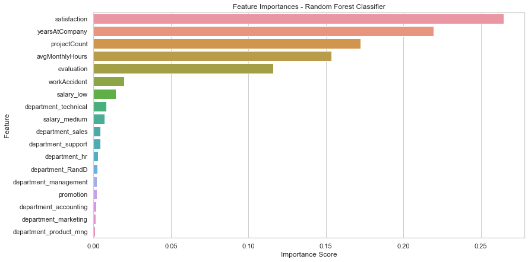

```python
sns.set(style="whitegrid")

plt.subplots(figsize=(13,7))
sns.barplot(y='index', x='importance', data=feature_importances)

plt.xlabel("Importance Score")
plt.ylabel("Feature")
plt.title("Feature Importances - Random Forest Classifier")
plt.show()
```

We can see that only the first 5 features significantly contribute to the model than the other remaining features. We can eliminate other low-score features and check the performance of the model.

## Prescriptive Analytics

### Retention Plan

We cannot solely depend on the output of our model since it is being used for people.Instead, we can use its probability output and design our own system to treat each employee accordingly.

```
1.Safe Zone (Green)  - This zone employees are considered safe.
2.Low Risk Zone (Yellow) - Should be taken into consideration.May become potential turnover eventually.
3.Medium Risk Zone (Orange) - These employees are at risk of turnover. Should be monitored and taken care accordingly.
4.High Risk Zone (Red) - These employees are at the highest peak of turnover.Should be acted upon immediately.
```

## What to Optimize

We want our ML model to catch as much as possible potential turnovers. Our target is to catch all of the higly probable turnover employees at the cost of flagging some low-risk non-turnover employee.(i.e in ML terms, limit the False Negatives even if it happens at the cost of False Positives).

### Solution 1:

- Ranking the employees by their probability of leaving, then allocating a limited incentive budget to the highest probable turnover instances.
- Or we can allocate the incentive budget to those employees which can incur highest loss if turnovered.This can be done with high-salary executives/employees, high or mid-level managers/team leads or senior team members.

### Solution 2:

- Developing learning programs for potential turnover employees.Then monitoring their performance and measure progress.
- Thanksgiving for team members' success.
- Helping team with career development.

## Requiring Special Focus:

1. When we talk about 'Turnover' feature, we don't know if the employees that left are interns, contractors, full-time or part-time.These are important aspects to be considered when building a predictive modeling solution since weights associated with the turnover costs for each type of employee varies accordingly. A high-salary employee would need a costlier form of treatment.
2. We may not be sure about the 'Evaluation' feature since evaluation is highly subjective, and can vary greatly based on who is the evaluator. If the employee and the evaluator knows each other, then he/she will mostly have a higher score.

## Final Thoughts:

Though low-turnover rate is the goal for most organizations, the benchmark for turnover rate varies accordingly depending upon the industry-type, type of job, company size, region, etc. Organizations have to consider the individual as well as industry-related factors into account as they decide their target turnover rate, learn reasons for turnover, and make changes to reduce the employee turnover rate and improve their workforce retention.

**Note:** This is a generic model built on a dataset provided by the Kaggle website. When one plans to design their own turnover prediction model, this project would be used as a reference template to start afresh. This project serves no real benefit unless modified or adjusted as per the requirements and factors affecting turnover of the organization(s) under study.